# Art History Data Anaysis

Tianyi Ma

In high school I took AP Art History. Although I only got a 3 out of 5 in the exam, which is one of my worst scores, I loved the subject since I get to look at a sea of artworks. TidyTuesday has a ton of fun datasets, but this one stood out to me because they actually extracted data from two Art History textbooks, and I think one of them is actually my high school Art History textbook. I’m compelled to analyze it at this point.

# Read Dataset

```r
library(tidytuesdayR)
tuesdata <- tidytuesdayR::tt_load('2023-01-17')
```

```
--- Compiling #TidyTuesday Information for 2023-01-17 ----
--- There is 1 file available ---
--- Starting Download ---
```

```
--- Download complete ---
```

```r
tuesdata <- tidytuesdayR::tt_load(2023, week = 03)
```

```
--- Compiling #TidyTuesday Information for 2023-01-17 ----
--- There is 1 file available ---
--- Starting Download ---
```

```
--- Download complete ---
```

```r
arthistory <- tuesdata$arthistory
```

It seems like the TidyTuesday version of the dataset only has artist.csv. This is a little disappointing since I originally considered the artwork data to be the meat of this dataset. Luckily the github README file for this dataset cited its original publish site, so I went on there and there it is, the instruction of downloading the full dataset. Let’s do it.

```r
install.packages("arthistory")
```

Now let’s take a quick look of the inside of the `worksgardner` dataset.

```r
library("arthistory")
```

```r
head(worksgardner, 5)
```

| artist_name | edition_number | title_of_work | publication_year | page_number_of_image | artist_unique_id | artist_nationality | artist_gender | artist_race | artist_ethnicity | height_of_work_in_book | width_of_work_in_book | height_of_text | width_of_text | extra_text_height | extra_text_width | area_of_work_in_book | area_of_text | extra_text_area | total_area_text | total_space | page_area | space_ratio_per_page | book |
| --- | --- | --- | --- | --- | --- | --- | --- | --- | --- | --- | --- | --- | --- | --- | --- | --- | --- | --- | --- | --- | --- | --- | --- |
| Aaron Douglas | 9 | Noah's Ark | 1991 | 965 | 1 | American | Male | Black or African American | Not Hispanic or Latinx | 11.3 | 8.5 | 14.5 | 8.4 | 0 | 0 | 96.05 | 121.80 | 0 | 121.80 | 217.85 | 616.50 | 0.3533658 | gardner |
| Aaron Douglas | 10 | Noah's Ark | 1996 | 1053 | 1 | American | Male | Black or African American | Not Hispanic or Latinx | 12.1 | 8.9 | 12.4 | 9.0 | 0 | 0 | 107.69 | 111.60 | 0 | 111.60 | 219.29 | 586.42 | 0.3739470 | gardner |
| Aaron Douglas | 11 | Noah's Ark | 2001 | 1030 | 1 | American | Male | Black or African American | Not Hispanic or Latinx | 12.3 | 8.8 | 10.8 | 9.0 | 0 | 0 | 108.24 | 97.20 | 0 | 97.20 | 205.44 | 677.44 | 0.3032593 | gardner |
| Aaron Douglas | 12 | Noah's Ark | 2005 | 990 | 1 | American | Male | Black or African American | Not Hispanic or Latinx | 12.3 | 8.8 | 15.7 | 8.9 | 0 | 0 | 108.24 | 139.73 | 0 | 139.73 | 247.97 | 657.66 | 0.3770489 | gardner |
| Aaron Douglas | 13 | Noah's Ark | 2009 | 937 | 1 | American | Male | Black or African American | Not Hispanic or Latinx | 12.8 | 9.3 | 15.0 | 9.3 | 0 | 0 | 119.04 | 139.50 | 0 | 139.50 | 258.54 | 648.93 | 0.3984097 | gardner |

Getting basic info on the data:

```r
str(worksgardner)
```

```
tibble [2,325 × 24] (S3: tbl_df/tbl/data.frame)
 $ artist_name           : chr [1:2325] "Aaron Douglas" "Aaron Douglas" "Aaron Douglas" "Aaron Douglas" ...
 $ edition_number        : num [1:2325] 9 10 11 12 13 14 15 16 14 15 ...
 $ title_of_work         : chr [1:2325] "Noah's Ark" "Noah's Ark" "Noah's Ark" "Noah's Ark" ...
 $ publication_year      : num [1:2325] 1991 1996 2001 2005 2009 ...
 $ page_number_of_image  : chr [1:2325] "965" "1053" "1030" "990" ...
 $ artist_unique_id      : num [1:2325] 1 1 1 1 1 1 1 1 2 2 ...
 $ artist_nationality    : chr [1:2325] "American" "American" "American" "American" ...
 $ artist_gender         : chr [1:2325] "Male" "Male" "Male" "Male" ...
 $ artist_race           : chr [1:2325] "Black or African American" "Black or African American" "Black or African American" "Black or African American" ...
 $ artist_ethnicity      : chr [1:2325] "Not Hispanic or Latinx" "Not Hispanic or Latinx" "Not Hispanic or Latinx" "Not Hispanic or Latinx" ...
 $ height_of_work_in_book: num [1:2325] 11.3 12.1 12.3 12.3 12.8 12.8 12.7 7.9 14 12.8 ...
 $ width_of_work_in_book : num [1:2325] 8.5 8.9 8.8 8.8 9.3 9.3 9.2 19 10.2 9.2 ...
 $ height_of_text        : num [1:2325] 14.5 12.4 10.8 15.7 15 18.8 21.2 14.7 4.5 16.2 ...
 $ width_of_text         : num [1:2325] 8.4 9 9 8.9 9.3 9.3 9.2 13.9 9.3 9.2 ...
 $ extra_text_height     : num [1:2325] 0 0 0 0 0 0 0 0 9.2 0 ...
 $ extra_text_width      : num [1:2325] 0 0 0 0 0 0 0 0 8.8 0 ...
 $ area_of_work_in_book  : num [1:2325] 96 108 108 108 119 ...
 $ area_of_text          : num [1:2325] 121.8 111.6 97.2 139.7 139.5 ...
 $ extra_text_area       : num [1:2325] 0 0 0 0 0 ...
 $ total_area_text       : num [1:2325] 121.8 111.6 97.2 139.7 139.5 ...
 $ total_space           : num [1:2325] 218 219 205 248 259 ...
 $ page_area             : num [1:2325] 616 586 677 658 649 ...
 $ space_ratio_per_page  : num [1:2325] 0.353 0.374 0.303 0.377 0.398 ...
 $ book                  : chr [1:2325] "gardner" "gardner" "gardner" "gardner" ...
 - attr(*, "spec")=
  .. cols(
  ..   ArtistName = col_character(),
  ..   EditionNumber = col_double(),
  ..   TitleofWork = col_character(),
  ..   Year = col_double(),
  ..   PageNumberofImage = col_character(),
  ..   ArtistUniqueID = col_double(),
  ..   ArtistNationality = col_character(),
  ..   ArtistGender = col_character(),
  ..   ArtistRace = col_character(),
  ..   ArtistEthnicity = col_character(),
  ..   `HeightofWorkinGardner(cm)*` = col_double(),
  ..   `WidthofWorkinGardner(cm)` = col_double(),
  ..   `LengthofText(cm)` = col_double(),
```

[output cut: 25 more lines]

[output not shown]

That is a little disappointing – I was expecting to see descriptive texts associated with each artwork. But this is okay. The size of the artwork and its texts also could be interesting.

Right now, though, we observe that the first 5 rows are all work called “Noah’s Ark” by Aaron Douglas, just in different editions of the book. Because I don’t care about different editions and sizes right now, I’ll simply remove every edition other than the latest one for every author and their artwork. Right now, I want to analyze artist and their artwork info. Later, we can try answer questions like “how many artworks are included in each edition” or “How many artworks are added for each edition”.

```r
library(dplyr)
worksgardner_lean <- worksgardner %>%
  group_by(artist_name, title_of_work) %>%
  filter(row_number() == n()) %>%
  ungroup()
head(worksgardner_lean, 2)
```

| artist_name | edition_number | title_of_work | publication_year | page_number_of_image | artist_unique_id | artist_nationality | artist_gender | artist_race | artist_ethnicity | height_of_work_in_book | width_of_work_in_book | height_of_text | width_of_text | extra_text_height | extra_text_width | area_of_work_in_book | area_of_text | extra_text_area | total_area_text | total_space | page_area | space_ratio_per_page | book |
| --- | --- | --- | --- | --- | --- | --- | --- | --- | --- | --- | --- | --- | --- | --- | --- | --- | --- | --- | --- | --- | --- | --- | --- |
| Aaron Douglas | 15 | Noah's Ark | 2016 | 912 | 1 | American | Male | Black or African American | Not Hispanic or Latinx | 12.7 | 9.2 | 21.2 | 9.2 | 0 | 0 | 116.84 | 195.04 | 0 | 195.04 | 311.88 | 646.70 | 0.4822638 | gardner |
| Aaron Douglas | 16 | From Slavery through Reconstruction, from Aspects of Negro Life | 2020 | 932 | 1 | American | Male | Black or African American | Not Hispanic or Latinx | 7.9 | 19.0 | 14.7 | 13.9 | 0 | 0 | 150.10 | 204.33 | 0 | 204.33 | 354.43 | 651.84 | 0.5437377 | gardner |

Further looking into some basic statistic in the new dataframe shows that the number of data points shrunk from 2300+ to ~750 artist-artwork pairs.

```r
str(worksgardner_lean)
```

[output not shown]

[output cut: 76 more lines]

[output not shown]

Now we can answer some question like “who’s the most popular artist according to this textbook?”. We will show this as a bar graph.

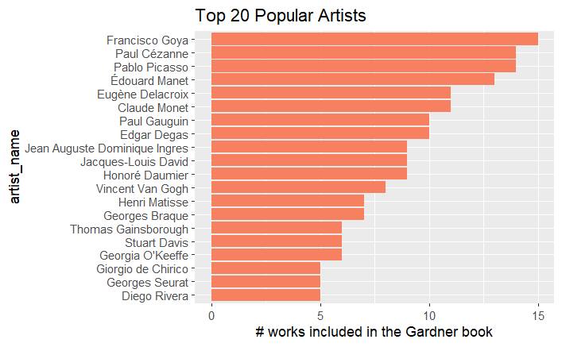

```r
library('ggplot2')
library('forcats')

artist_work_num_rank <- worksgardner_lean %>%
                          count(artist_name, sort = T)

artist_work_num_rank %>%
    mutate(artist_name = fct_reorder(artist_name, n)) %>%
    slice(1:20) %>%
    ggplot(., aes(x=artist_name, y=n)) +
    geom_bar(stat = "identity", fill="#f68060") +
    coord_flip() +
    ggtitle('Top 20 Popular Artists') +
    ylab('# works included in the Gardner book')
```

```r
artist_work_num_rank
```

| artist_name | n |
| --- | --- |
| Francisco Goya | 15 |
| Pablo Picasso | 14 |
| Paul Cézanne | 14 |
| Édouard Manet | 13 |
| Claude Monet | 11 |
| Eugène Delacroix | 11 |
| Edgar Degas | 10 |
| Paul Gauguin | 10 |
| Honoré Daumier | 9 |
| Jacques-Louis David | 9 |

[output cut: 324 more lines]